# Determinar a eficiência do ciclo Rankine com reaquecimento

(2 Turbinas - HP e LP) Copyright: Luiz Chaves

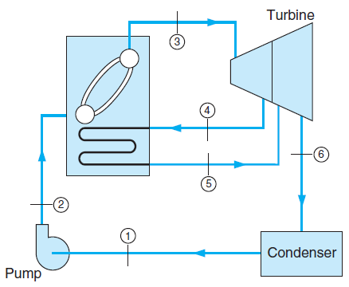

Disciplina EPP (Engenharia de Produto e Processos) Autor: Luiz Chaves Ano: 2022

Procedimento: 1 - Importar os pacotes. Principalmente o PYROmat que deve ser obtido e instalado no prompt do Anaconda. 2 - Configurar as unidades 3 - O fluido é vapor d´água.

Acesse a página para instalar e saber mais do Thermodynamic Properties in Python: http://www.pyromat.org/

```python
import pyromat as pm
import numpy as np

# Configuração para operar na unidade MPa - ok.
pm.config["unit_pressure"]="MPa"

# Configuração para operar na unidade K - ok.


# Define as propridades da água
mp_water=pm.get("mp.H2O")
```

4 - Definir as propopriedades para cada ponto. Partindo da bomba e correntes 1 e 2:

```python
#Líquido saturado, pois é bomba, dessa forma: x = 0
# Atenção que s1 e s2 são iguais pois a bomba é isentrópica. O processo ocorre de forma rápida e direta sem haver
# a desorganização do sistema.

p1 = 0.800
T1 = 40 + 273.15
h1 = mp_water.h(p=p1, T=T1)


T2=40 + 273.15
p2 = 25
# s2 = s1
h2 = mp_water.h(p=p2,T=T2)

# As condições da corrente 3 em relação a 2 são as mesmas para P2 = P3. Correto?


# Estimativa do volume específico
ve = 1/mp_water.ds(p=p1)[0]

w_p = ve*(p2-p1)

mdot=7.5  # kg/s
Taxa_trabalho_bomba = mdot*(h2-h1)


# Respostas:
print(f"Dados da bomba devem ser obtidos pelo volume específico do fluido:")
print(f"___________________________________________________________________")
print(f"Volume específico do fluido: {round(float(ve),5)} m^3/kg")
print(f"Entalpia da corrente 1 (H1 fluido): {round(float(h1),5)} kJ/kg")
print(f"Entalpia da corrente 2 (H2 fluido): {round(float(h2),5)} kJ/kg")
print(f"Trabalho requerido pela bomba por unidade de massa: {round(float(w_p),7)} kJ/kg")
print(f"Taxa de trabalho da bomba: {round(float(Taxa_trabalho_bomba/1000),1)} MW")
```

```
Dados da bomba devem ser obtidos pelo volume específico do fluido:
___________________________________________________________________
Volume específico do fluido: 0.00111 m^3/kg
Entalpia da corrente 1 (H1 fluido): 168.23711 kJ/kg
Entalpia da corrente 2 (H2 fluido): 189.53575 kJ/kg
Trabalho requerido pela bomba por unidade de massa: 0.0269777 kJ/kg
Taxa de trabalho da bomba: 0.2 MW
```

5 - Obter os dados dos pontos 3 , 4 e assim por diante, para cada corrente - stream i

```python
p3 = p2
T3 = 550 + 273.15
h3 = mp_water.h(p=p3, T=T3)
s3 = mp_water.s(p=p3, T=T3)
Qdot = mdot*(h3-h2)
print("          Taxa de Energia do Boiler ")
print("_________________________________________________________ ")
print(f"Entalpia da corrente 3 [h3]: {round(float(h3),4)} kJ/kg")
print(f"Taxa de calor de Aquecimento [Q]: {round(float(Qdot/1000),4)} MW")
```

```
          Taxa de Energia do Boiler
_________________________________________________________
Entalpia da corrente 3 [h3]: 3339.2416 kJ/kg
Taxa de calor de Aquecimento [Q]: 23.6228 MW
```

```python
p4 = 4
s4 = s3
T4 = 300+273.15
h4 = mp_water.h(T=T4, p=p4)

w_HPt = h3-h4
w_HPdot = mdot*(h3-h4)
print("Geração de Energia da Turbina HP ")
print("________________________________________________________________")
print(f"Entalpia da corrente 4 [h4]: {round(float(h4),1)} kJ/kg")
print(f"Trabalho gerado pelo expansor ou turbina HP: {round(float(w_HPt),1)} kJ/kg")
print(f"Taxa de Trabalho do expansor ou turbina HP: {round(float(w_HPdot/1000),1)} MW")
```

```
Geração de Energia da Turbina HP
________________________________________________________________
Entalpia da corrente 4 [h4]: 2961.7 kJ/kg
Trabalho gerado pelo expansor ou turbina HP: 377.5 kJ/kg
Taxa de Trabalho do expansor ou turbina HP: 2.8 MW
```

```python
p5 = p4
T5 = 550 + 273.15
h5 = mp_water.h(p=p5, T=T5)
s5 = mp_water.s(p=p5, T=T5)
Qin=(h5-h4)
Qreq=mdot*(h5-h4)
print(f"          Taxa de Energia no Reaquecimento (Boiler) ")
print("_________________________________________________________ ")
print(f"Entalpia da corrente 5 [h5]: {round(float(h5),4)} kJ/kg")

print(f"Energia do Reaquecimento: {round(float(Qin),4)} kJ/kg")
print(f"Calor Gerado no reaquecimento [QReaq]: {round(float(Qreq/1000),5)} MW")
```

```
          Taxa de Energia no Reaquecimento (Boiler)
_________________________________________________________
Entalpia da corrente 5 [h5]: 3560.3735 kJ/kg
Energia do Reaquecimento: 598.6485 kJ/kg
Calor Gerado no reaquecimento [QReaq]: 4.48986 MW
```

```python
p6=0.010 # Unidade MPa

h6 = mp_water.h(x=0.95, p=p6)
WLP=mdot*(h5-h6)

print("          Taxa de Energia na Turbina LP ")
print("_________________________________________________________ ")
print(f"Entalpia da corrente 6 [h6]: {round (float(h6),7)} kJ/kg")
print(f"Energia por unidade de massa no expansor / turbina LP [WLP]: {round (float((h5-h6)),5)} kJ/kg")
print(f"Taxa de trabalho na Turbina LP [WLP]: {round (float(WLP/1000),7)} MW")
```

```
          Taxa de Energia na Turbina LP
_________________________________________________________
Entalpia da corrente 6 [h6]: 2464.2802614 kJ/kg
Energia por unidade de massa no expansor / turbina LP [WLP]: 1096.09321 kJ/kg
Taxa de trabalho na Turbina LP [WLP]: 8.2206991 MW
```

# Tabela de Resultados

```python
import pandas as pd
```

```python
df = pd.DataFrame({
    'Número': [1, 2, 3, 4, 5, 6],
    'Entalpia': ['h1', 'h2', 'h3', 'h4', 'h5', 'h6'],
    'Valor (kJ/kg)': [h1, h2, h3, h4, h5, h6]},
    index=['Condensador/Bomba', 'Bomba/Boiler', 'Boiler/Turbina HP', 'Turbina HP/Boiler Reaqu.', 'Boiler Reaq./Turbina LP',
           'Turbina LP/Condensador'])
```

```python
print(df.to_string())
```

```
                          Número Entalpia         Valor (kJ/kg)
Condensador/Bomba              1       h1  [168.23710709346378]
Bomba/Boiler                   2       h2  [189.53575059411773]
Boiler/Turbina HP              3       h3   [3339.241615913974]
Turbina HP/Boiler Reaqu.       4       h4   [2961.724997495932]
Boiler Reaq./Turbina LP        5       h5  [3560.3734753514627]
Turbina LP/Condensador         6       h6   [2464.280261421838]
```

```python
Q_total = mdot*((h3-h2)+(h5-h4))
W_turbinas= mdot*((h5-h6) +(h3 - h4))
Wpump=Taxa_trabalho_bomba/1000

print("-----------------------------RESUMO ------------------------------------")
print(f"Taxa de trabalho da Bomba: {round(float(Wpump),1)} kW")
print(f"Calor fornecido pelo boiler no sistema (Q + Qreaq): {round(float(Q_total),1)} kW")

print(f"Trabalho Total das turibnas (LP + HP): {round(float(W_turbinas),1)} MW")
```

[output not shown]

```python
Qc = h6-h1
print(f"Calor removido do condensador: {round(float(Qc),1)} kJ/kg")
```

```
Calor removido do condensador: 2296.0 kJ/kg
```

6 - Calcular a eficiência que é o indicador desejado para estimar o desempenho do sistema para posterior estudo comparativo.

```python
eta = (W_turbinas-Wpump)/Q_total*100
print(f"Eficiência térmica do ciclo termodinâmico: {round(float(eta),5)}%")
```

```
Eficiência térmica do ciclo termodinâmico: 39.31295%
```